# Unit 11

11.2.6 White Noise and Whitening the Residuals Simulated Seasonal Data

```r
x=gen.aruma.wge(n=200,s=12,phi=c(1.5,-.8),sn=87)
```

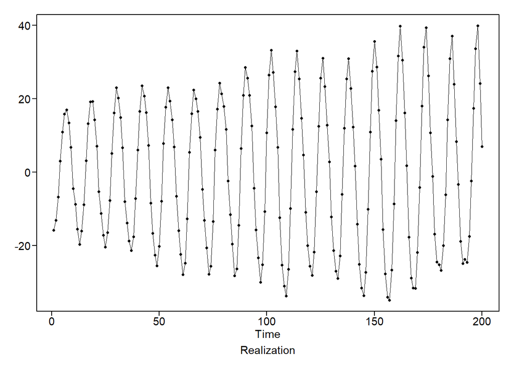

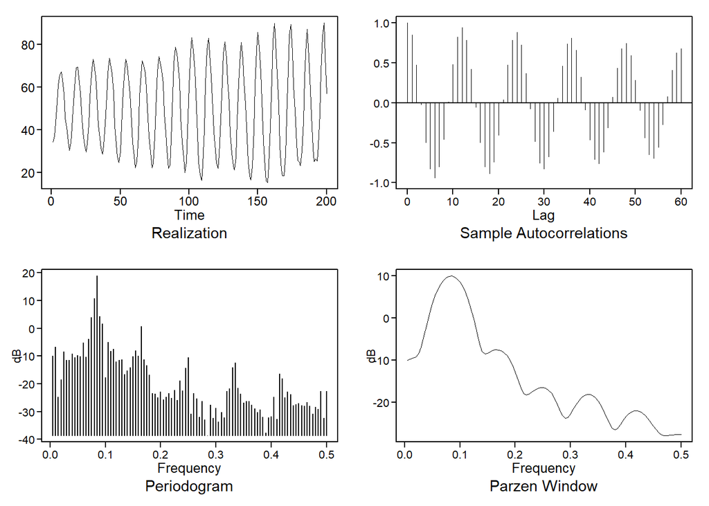

```r
x=x+50
plotts.sample.wge(x,lag.max=60)
```

Modeling the data: Overfit tables suggested a factor of (1-B^12) We transformed the data by (1-B^12)

```r
y=artrans.wge(x,phi.tr=c(0,0,0,0,0,0,0,0,0,0,0,1))
```

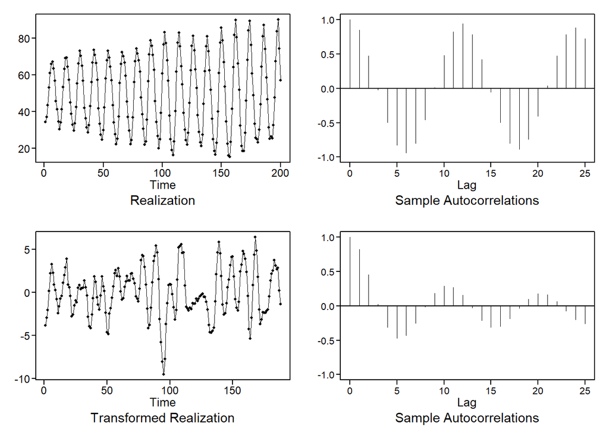

. Transformed data appeared to be stationary

. After transforming the data we used BIC which selected an AR(2) model

```r
est.y=est.ar.wge(y,p=2)
```

```
##
## Coefficients of Original polynomial:
## 1.4653 -0.7597
##
## Factor                 Roots                Abs Recip    System Freq
## 1-1.4653B+0.7597B^2    0.9644+-0.6215i      0.8716       0.0911
##
##
##
## Coefficients of Original polynomial:
## 1.4653 -0.7597
##
## Factor                 Roots                Abs Recip    System Freq
## 1-1.4653B+0.7597B^2    0.9644+-0.6215i      0.8716       0.0911
##
##
```

. And obtained the fitted model
$$(1-B^{12})(1-1.47B+0.76B^2)(X_t-49.78)=a_t\ \sigma^2_a=1.04$$

How about the residuals in est.y$res?

**Check 1:** Examine plots of residuals and their sample autocorrelations

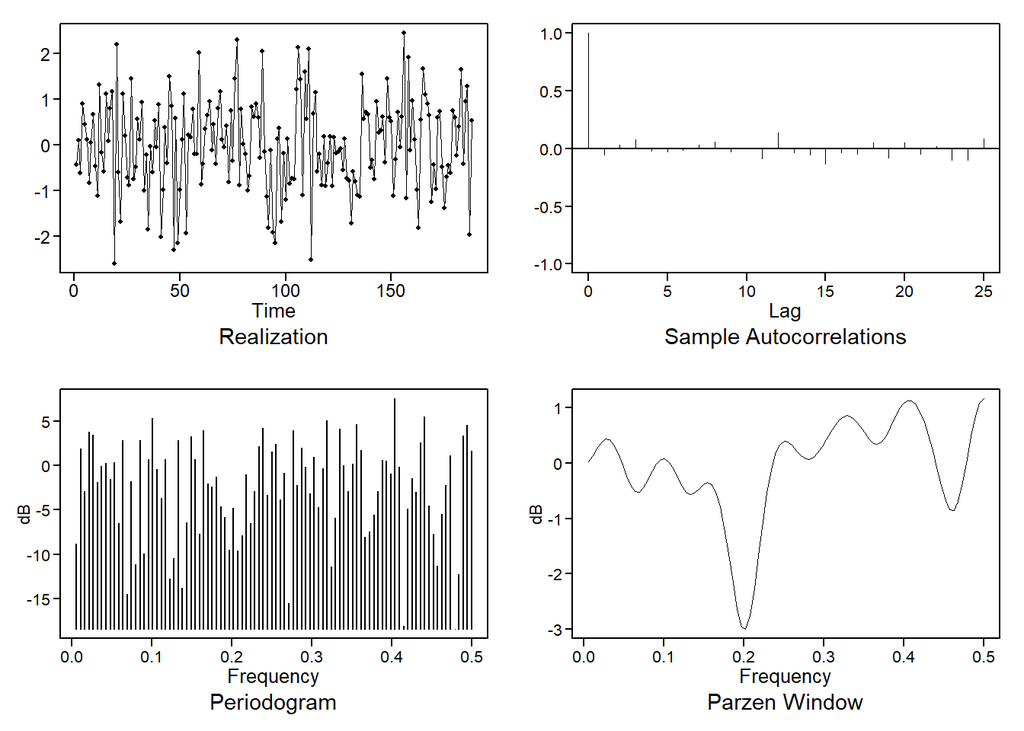

```r
plotts.sample.wge(est.y$res)
```

. Residuals look “white”

. Residual sample autocorrelations within 95% limit lines

**Check 2:** Ljung-Box test

**Recall:** When we fit an ARIMA or Seasonal Model, we transform the data to stationarity. The p and q in the Ljung-Box call statement are for the estimation of the stationary component. (in this case p=2)

```r
ljung.wge(est.y$res,p=2)
```

```
## Obs -0.05396165 0.03189607 0.07701788 -0.01893052 -0.02864166 -0.0134751 0.0323827 0.05653615 -0.02845631 0.003893939 -0.08586993 0.1346106 -0.03365496 -0.0552793 -0.133867 -0.03486653 -0.04390713 0.05083349 -0.08191827 0.05110639 -0.04547363 0.02093602 -0.09782859 -0.1023762
```

```
## $test
## [1] "Ljung-Box test"
##
## $K
## [1] 24
##
## $chi.square
## [1] 20.95537
##
## $df
## [1] 22
##
## $pval
## [1] 0.5234977
```

```r
ljung.wge(est.y$res,p=2,K=48)
```

```
## Obs -0.05396165 0.03189607 0.07701788 -0.01893052 -0.02864166 -0.0134751 0.0323827 0.05653615 -0.02845631 0.003893939 -0.08586993 0.1346106 -0.03365496 -0.0552793 -0.133867 -0.03486653 -0.04390713 0.05083349 -0.08191827 0.05110639 -0.04547363 0.02093602 -0.09782859 -0.1023762 0.08311386 -0.168667…
```

```
## $test
## [1] "Ljung-Box test"
##
## $K
## [1] 48
##
## $chi.square
## [1] 47.62509
##
## $df
## [1] 46
##
## $pval
## [1] 0.4063877
```

For both K=24 and 48 we **fail to reject white noise**. Based on Checks 1 and 2 the residuals from the fitted seasonal model **seem to be white**.

#### Log Airline Data

In order to analyze the residuals, we recreate the steps necessary to retrieve them in tswge.

Transform Data

```r
data(airlog)
# transform data
# Difference the data
d1=artrans.wge(airlog,phi.tr=1)
```

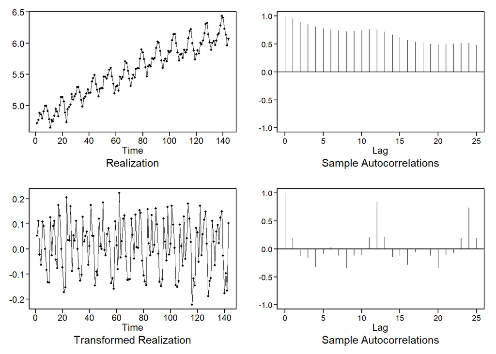

Transform differenced data by $(1-B^{12})$

```r
s12=c(0,0,0,0,0,0,0,0,0,0,0,1)
d1.12=artrans.wge(d1,phi.tr=s12)
```

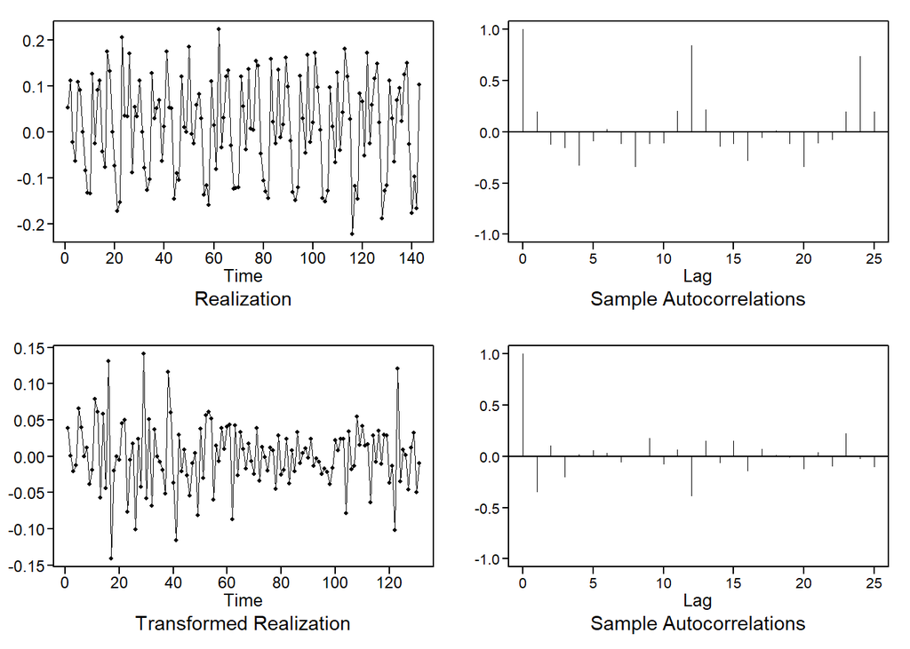

aic and aicc pick ARMA(12,1)

```r
aic.wge(d1.12,p=0:15,q=0:3)
```

```
## $type
## [1] "aic"
##
## $value
## [1] -6.423649
##
## $p
## [1] 12
##
## $q
## [1] 1
##
## $phi
##  [1]  0.00846435  0.07967002 -0.10710183 -0.02069279  0.08039524  0.04050674
##  [7] -0.05516681  0.03629598  0.13277817 -0.05297698 -0.12340975 -0.40343184
##
## $theta
## [1] 0.4536856
##
## $vara
## [1] 0.001310444
```

```r
# estimate parameters of stationary part
est.12.1=est.arma.wge(d1.12,p=12,q=1)
```

```
##
## Coefficients of Original polynomial:
## 0.0085 0.0797 -0.1071 -0.0207 0.0804 0.0405 -0.0552 0.0363 0.1328 -0.0530 -0.1234 -0.4034
##
## Factor                 Roots                Abs Recip    System Freq
## 1-1.3375B+0.9189B^2    0.7278+-0.7474i      0.9586       0.1271
## 1-0.4595B+0.9145B^2    0.2512+-1.0151i      0.9563       0.2114
## 1-1.8218B+0.8847B^2    1.0296+-0.2650i      0.9406       0.0401
## 1+1.8049B+0.8709B^2   -1.0363+-0.2728i      0.9332       0.4590
## 1+1.2840B+0.8214B^2   -0.7816+-0.7788i      0.9063       0.3753
## 1+0.5214B+0.7586B^2   -0.3436+-1.0955i      0.8710       0.2984
##
##
```

The residuals are in est.12.1$res  
**Check 1:** Examine residuals and their sample autocorrelations

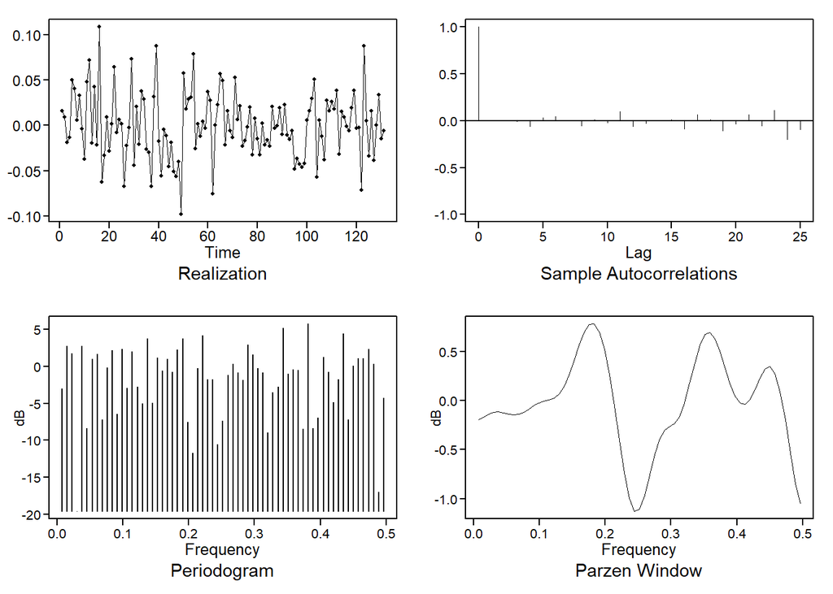

```r
plotts.sample.wge(est.12.1$res)
```

```r
ljung.wge(est.12.1$res,p=12,q=1)
```

```
## Obs -0.001547552 0.001360418 -0.006397308 -0.05888546 0.03415626 0.04476322 -0.003899276 -0.05226885 0.009324076 -0.02364796 0.1001679 -0.06199779 -0.02696648 0.001423601 0.0134558 -0.08571758 0.06526091 0.01255757 -0.1090628 -0.03670785 0.0635192 -0.05669719 0.1146161 -0.2017091
```

```
## $test
## [1] "Ljung-Box test"
##
## $K
## [1] 24
##
## $chi.square
## [1] 17.30648
##
## $df
## [1] 11
##
## $pval
## [1] 0.09913114
```

```r
ljung.wge(est.12.1$res,p=12,q=1,K=48)
```

```
## Obs -0.001547552 0.001360418 -0.006397308 -0.05888546 0.03415626 0.04476322 -0.003899276 -0.05226885 0.009324076 -0.02364796 0.1001679 -0.06199779 -0.02696648 0.001423601 0.0134558 -0.08571758 0.06526091 0.01255757 -0.1090628 -0.03670785 0.0635192 -0.05669719 0.1146161 -0.2017091 -0.09260232 0.04…
```

```
## $test
## [1] "Ljung-Box test"
##
## $K
## [1] 48
##
## $chi.square
## [1] 35.93309
##
## $df
## [1] 35
##
## $pval
## [1] 0.4245906
```

**Next Steps:**  
**Answer Questions of Interest**  
The question of interest may have been to forecast the number of airline passengers two months later and to quantify our uncertainty.

```r
TwoMonthFore= fore.aruma.wge(airlog,d = 1, s = 12, phi = est.12.1$phi, theta = est.12.1$theta,n.ahead = 2, limits = TRUE)
```

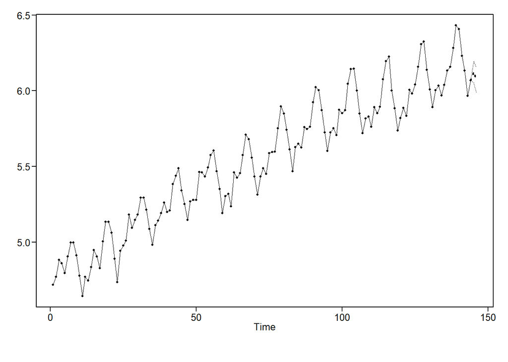

```r
TwoMonthFore
```

```
## $f
## [1] 6.124662 6.070614
##
## $ll
## [1] 6.053338 5.989049
##
## $ul
## [1] 6.195986 6.152180
##
## $resid
##   [1]  0.000000e+00  0.000000e+00  0.000000e+00  0.000000e+00  0.000000e+00
##   [6]  0.000000e+00  0.000000e+00  0.000000e+00  0.000000e+00  0.000000e+00
##  [11]  0.000000e+00  0.000000e+00  0.000000e+00  0.000000e+00  0.000000e+00
##  [16]  0.000000e+00  0.000000e+00  0.000000e+00  0.000000e+00  0.000000e+00
##  [21]  0.000000e+00  0.000000e+00  0.000000e+00  0.000000e+00  0.000000e+00
```

[output cut: 43 more lines]

**Conclusion:** In two months we are 95% confident that the number of airline passengers will be between 399,415 (e5.99 1000) and 468,717 (e6.15 1000) passengers. Our best estimate is 432,681 (e6.07 1000) passengers.  
We have to convert back from the log data.

#### 11.3.1 Con Check

Step 1: Use the code below to fit the model.  
Step 2: Obtain and plot the residuals, and plot the ACF of the residuals.  
**Question:**  
Do the residuals and ACF look consistent with white noise?

```r
data(airlog) # load from tswge package
airlog1 = artrans.wge(airlog,phi.tr=1)
```

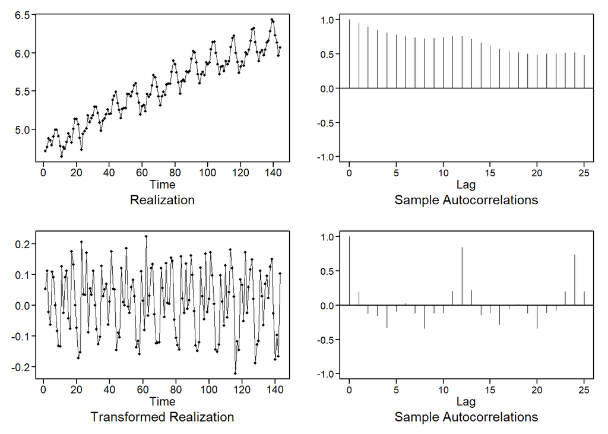

```r
airlog1.12 = artrans.wge(airlog1,phi.tr = c(rep(0,11),1))
```

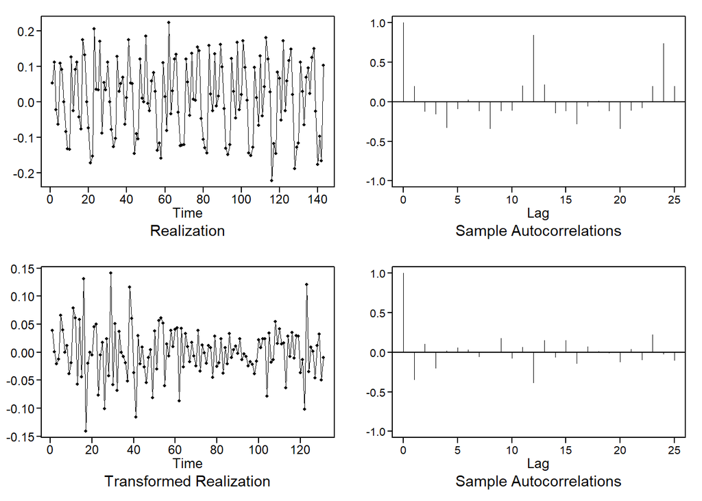

```r
ww = est.ar.wge(airlog1.12,p = 12)
```

```
##
## Coefficients of Original polynomial:
## -0.3666 -0.0615 -0.1326 -0.1063 0.0284 0.0630 -0.0299 0.0184 0.1601 0.0408 -0.1056 -0.3943
##
## Factor                 Roots                Abs Recip    System Freq
## 1-0.4237B+0.9156B^2    0.2314+-1.0191i      0.9569       0.2145
## 1+1.8377B+0.9001B^2   -1.0208+-0.2626i      0.9488       0.4599
## 1-1.2905B+0.8901B^2    0.7249+-0.7733i      0.9435       0.1301
## 1+1.3407B+0.8522B^2   -0.7866+-0.7448i      0.9231       0.3793
## 1+0.6095B+0.8085B^2   -0.3769+-1.0463i      0.8992       0.3050
## 1-1.7070B+0.7800B^2    1.0942+-0.2912i      0.8832       0.0414
##
##
##
## Coefficients of Original polynomial:
## -0.3666 -0.0615 -0.1326 -0.1063 0.0284 0.0630 -0.0299 0.0184 0.1601 0.0408 -0.1056 -0.3943
##
## Factor                 Roots                Abs Recip    System Freq
## 1-0.4237B+0.9156B^2    0.2314+-1.0191i      0.9569       0.2145
## 1+1.8377B+0.9001B^2   -1.0208+-0.2626i      0.9488       0.4599
## 1-1.2905B+0.8901B^2    0.7249+-0.7733i      0.9435       0.1301
## 1+1.3407B+0.8522B^2   -0.7866+-0.7448i      0.9231       0.3793
## 1+0.6095B+0.8085B^2   -0.3769+-1.0463i      0.8992       0.3050
## 1-1.7070B+0.7800B^2    1.0942+-0.2912i      0.8832       0.0414
##
##
```

Step 3: Perform the Ljung-Box test on the residuals.

```r
ljung.wge(ww$res,p=12)
```

```
## Obs -0.05269415 -0.01195705 0.009215204 -0.03554228 0.03698929 0.05080199 0.01201094 -0.06614542 0.01010035 -0.06529586 0.1080724 -0.09876449 -0.1534254 -0.005551179 0.009486911 -0.08830789 0.08509951 0.02272741 -0.1268933 -0.03064973 0.07985664 -0.04487249 0.1570919 -0.1809015
```

```
## $test
## [1] "Ljung-Box test"
##
## $K
## [1] 24
##
## $chi.square
## [1] 24.67346
##
## $df
## [1] 12
##
## $pval
## [1] 0.01644833
```

#### 11.4 Global Temperature Data

**Does the model make sense?**  
Another important check for model appropriateness  
. Stationary vs. nonstationary  
. Seasonal vs. non-seasonal  
. Correlation-based vs. signal-plus-noise model  
. Are characteristics of fitted model consistent with those of the data  
+ Forecasts and spectral estimates make sense?  
+ Do realizations and their characteristics behave like the data?

**a) Fitting a stationary model to the data:**

```r
data(hadley)
mean(hadley) #-0.1684937
```

```
## [1] -0.1684937
```

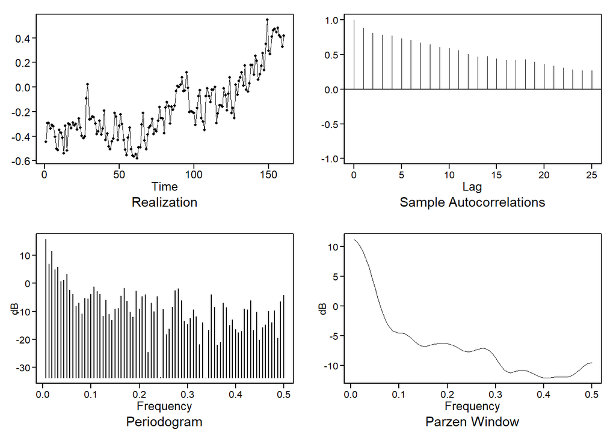

[output not shown]

[output cut: 33 more lines]

```r
plotts.sample.wge(hadley)
```

```r
aic5.wge(hadley,p=0:6,q=0:1)
```

```
## ---------WORKING... PLEASE WAIT...
##
##
## Five Smallest Values of  aic
```

```
##       p    q        aic
## 8     3    1  -4.471114
## 9     4    0  -4.470358
## 10    4    1  -4.461045
## 12    5    1  -4.460449
## 13    6    0  -4.459879
```

AIC picks an ARMA(3,1) stationary model

```r
had.est=est.arma.wge(hadley,p=3,q=1)
```

```
##
## Coefficients of Original polynomial:
## 1.2700 -0.4685 0.1912
##
## Factor                 Roots                Abs Recip    System Freq
## 1-0.9920B              1.0081               0.9920       0.0000
## 1-0.2780B+0.1927B^2    0.7212+-2.1606i      0.4390       0.1987
##
##
```

```r
# $phi: 1.2700171 -0.4685313  0.1911988
# $theta: 0.6322319
# $avar: 0.01074178
```

**Fitted ARMA(3,1) model:**
$$(1-1.27B+0.47B^2-0.19B^3)(X_t+.17)=(1-0.63B)a_t\\ where\ \sigma^2_a=0.0107$$
or in factored form using the factor table:
$$(1-0.99B)(1-0.28B+0.19B^2))(X_t+0.17)=(1-0.63B)a_t$$
(this is a “nearly nonstationary” model)
**Check residuals**

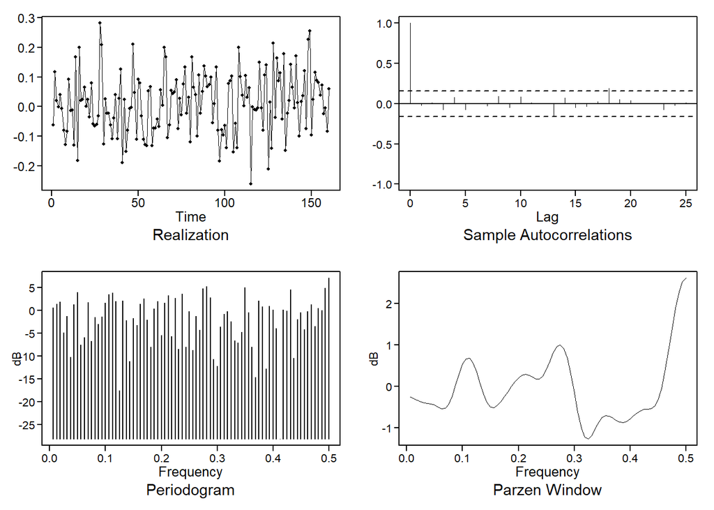

```r
plotts.sample.wge(had.est$res,arlimits=TRUE)
```

```r
ljung.wge(had.est$res,p=3,q=1)
```

```
## Obs -0.01824107 0.01280668 -0.07313631 0.08149021 -0.07315619 0.003804047 -0.02831738 0.08945443 -0.04586797 0.08328834 0.01553632 -0.0005732012 -0.1570195 0.07412384 -0.04809067 -0.03618193 0.0252044 0.1900964 0.05120468 0.04037613 -0.002901668 0.008261651 -0.07175151 -0.01892882
```

```
## $test
## [1] "Ljung-Box test"
##
## $K
## [1] 24
##
## $chi.square
## [1] 20.59104
##
## $df
## [1] 20
##
## $pval
## [1] 0.4215446
```

```r
ljung.wge(had.est$res,p=3,q=1,K=48)
```

```
## Obs -0.01824107 0.01280668 -0.07313631 0.08149021 -0.07315619 0.003804047 -0.02831738 0.08945443 -0.04586797 0.08328834 0.01553632 -0.0005732012 -0.1570195 0.07412384 -0.04809067 -0.03618193 0.0252044 0.1900964 0.05120468 0.04037613 -0.002901668 0.008261651 -0.07175151 -0.01892882 0.0105047 0.089…
```

```
## $test
## [1] "Ljung-Box test"
##
## $K
## [1] 48
##
## $chi.square
## [1] 45.4633
##
## $df
## [1] 44
##
## $pval
## [1] 0.4108957
```

Residuals look “white” and residual sample autocorrelations stay sufficiently within 95% limit lines  
**Ljung-Box results**  
P-values for K=24and K=48are 0.42and 0.41, respectively.  
**Conclusion:** Residuals for stationary **ARMA(3,1)** fit appear to be white.

#### Nonstationary Model

**b) Nonstationary model fit to temperature data:**  
Suppose that based on the evidence we make the decision to fit an ARIMA model to the temperature data.  
. (Even though the model checks: white noise residuals, realizations that have the appearance of the data, etc. were good for the ARMA model)

In this case we proceed by differencing the hadley data.

```r
d1.temp=artrans.wge(hadley,phi.tr=1)
```

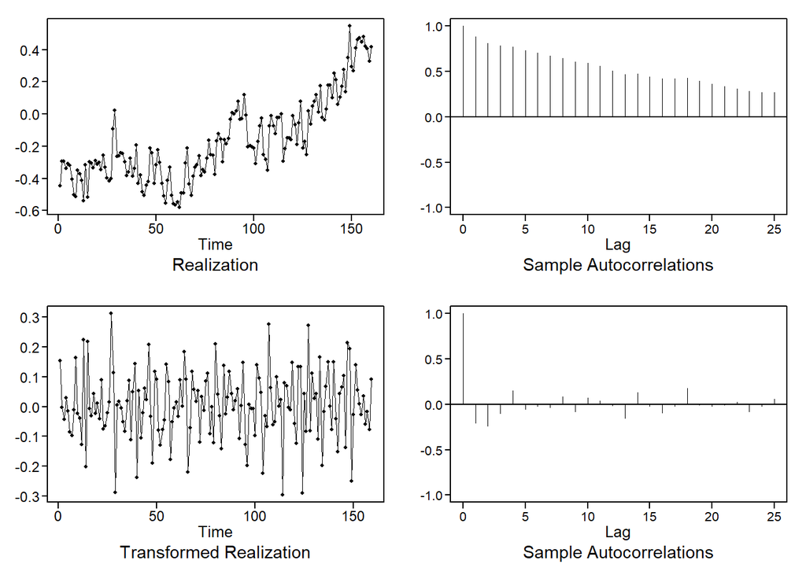

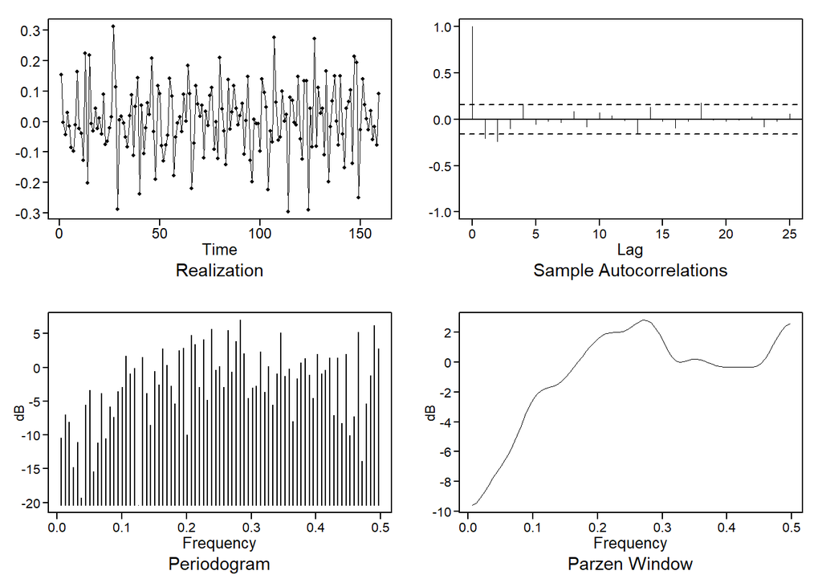

```r
plotts.sample.wge(d1.temp,arlimits=TRUE)
```

. The differenced data appear to be stationary  
+ And nearly “white” . However, the fact that the first two sample autocorrelations are outside the limits lines suggests that we continue to model  
**Model the differenced data**

```r
aic5.wge(d1.temp,p=0:6,q=0:1)
```

```
## ---------WORKING... PLEASE WAIT...
##
##
## Five Smallest Values of  aic
```

```
##       p    q        aic
## 6     2    1  -4.497695
## 4     1    1  -4.487947
## 8     3    1  -4.485866
## 7     3    0  -4.484722
## 10    4    1  -4.480622
```

AIC selects an ARMA(2,1)

```r
d1.temp.est=est.arma.wge(d1.temp,p=2,q=1)
```

```
##
## Coefficients of Original polynomial:
## 0.3274 -0.1787
##
## Factor                 Roots                Abs Recip    System Freq
## 1-0.3274B+0.1787B^2    0.9162+-2.1811i      0.4227       0.1867
##
##
```

```r
# $phi: 0.3274341 -0.1786827
# $theta: 0.704618
# $avar: 0.01058826
mean(hadley)
```

```
## [1] -0.1684937
```

**Fitted ARIMA(2,1,1) model:**
$$(1-B)(1-0.33B+0.18B^2)(X_t+0.17)=(1-0.70B)a_t\\ where\ \widehat{\sigma}^2_a=0.0106$$
**Check residuals**

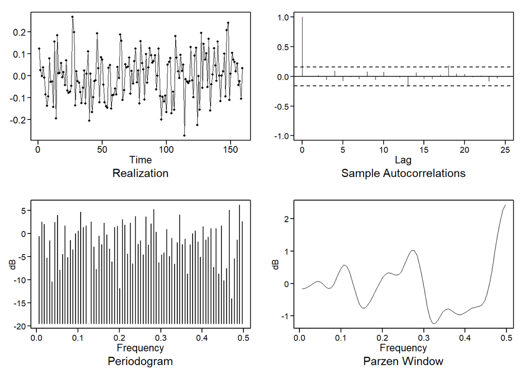

```r
plotts.sample.wge(d1.temp.est$res,arlimits=TRUE)
```

Residuals look “white” and residual sample autocorrelations stay sufficiently within 95% limit lines.  
**Ljung-Box results**

```r
ljung.wge(d1.temp.est$res,p=2,q=1)
```

```
## Obs -0.003065522 0.01677049 -0.0552273 0.09340698 -0.07179744 -0.00656664 -0.03871707 0.07729122 -0.05193401 0.07038592 0.006038737 -0.01424329 -0.1529827 0.06559275 -0.03951782 -0.04000431 0.02264002 0.1863673 0.04465521 0.03564069 -0.005552199 0.009283683 -0.07764581 -0.02798054
```

```
## $test
## [1] "Ljung-Box test"
##
## $K
## [1] 24
##
## $chi.square
## [1] 19.20029
##
## $df
## [1] 21
##
## $pval
## [1] 0.5722933
```

```r
ljung.wge(d1.temp.est$res,p=2,q=1,K=48)
```

```
## Obs -0.003065522 0.01677049 -0.0552273 0.09340698 -0.07179744 -0.00656664 -0.03871707 0.07729122 -0.05193401 0.07038592 0.006038737 -0.01424329 -0.1529827 0.06559275 -0.03951782 -0.04000431 0.02264002 0.1863673 0.04465521 0.03564069 -0.005552199 0.009283683 -0.07764581 -0.02798054 0.004464665 0.0…
```

```
## $test
## [1] "Ljung-Box test"
##
## $K
## [1] 48
##
## $chi.square
## [1] 44.86728
##
## $df
## [1] 45
##
## $pval
## [1] 0.4775275
```

**Clearly:** The two models are quite similar to each other.  
. The main difference is the stationary factor $(1-0.99B)$ vs. the nonstationary factor $(1-B)$  
. Residuals appear to be white for both models  
. Realizations from the two models are similar

**How about forecasts?**  
Forecasts using stationary model:

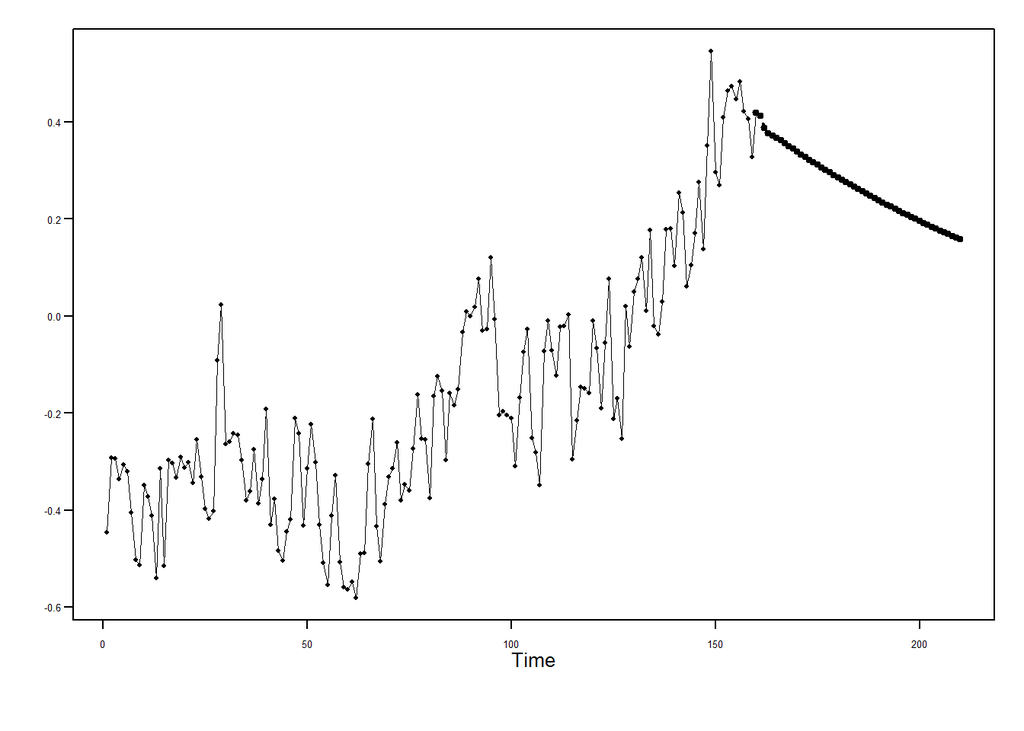

```r
data(hadley)
fore.arma.wge(hadley,phi=c(1.27,-.47,.19), theta=.63,n.ahead=50,limits=FALSE)
```

Forecasts using nonstationary model:

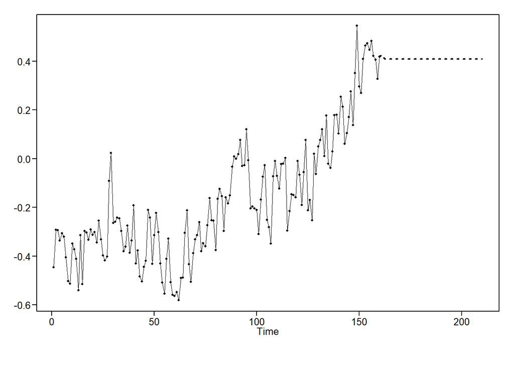

```r
fore.aruma.wge(hadley,d=1,phi=c(.33,-.18), theta=.7,n.ahead=50,limits=FALSE)
```

**Caution:** The decision concerning whether the observed warming trend should be predicted to continue is one that involves a variety of climatological issues we are not discussing here.  
**We simply ask the question:**  
Given reasonable models fit to the historical data, would these models predict the current trend to continue?  
. The answer is “No” based on the standard ARMA and ARIMA fits to the temperature data  
. Which seem like reasonable models and easily passed the checks for white noise residuals, etc.  
. So, is there any statistical argument for claiming the trend should continue?

#### Fitting Signal-Plus-Noise Models

For purposes of this example, we will use the Cochrane-Orcutt procedure for testing for trend in the temperature data set.  
1. Fit a regression line to the data and find the residuals from the line

```r
x=hadley
n=length(x)
t=1:n
d=lm(x~t)
#Find the residuals
x.z=x-d$coefficients[1]-d$coefficients[2]*t
#x.zare the residuals from the regression line
```

2. Fit an AR(p) model $\widehat{\phi}_z(B)$ to the residuals and find $\widehat{Y}_t=\widehat{\phi}_z(B)X_t$  
   ($\widehat{Y}_t=$y.trans in the code below)

```r
ar.z=aic.wge(x.z,p=0:6)
#ar.z$pis the order p
#ar.z$phiis vector of ar.z$pestimated AR coefficients
y.trans=artrans.wge(hadley,phi.tr=ar.z$phi)
```

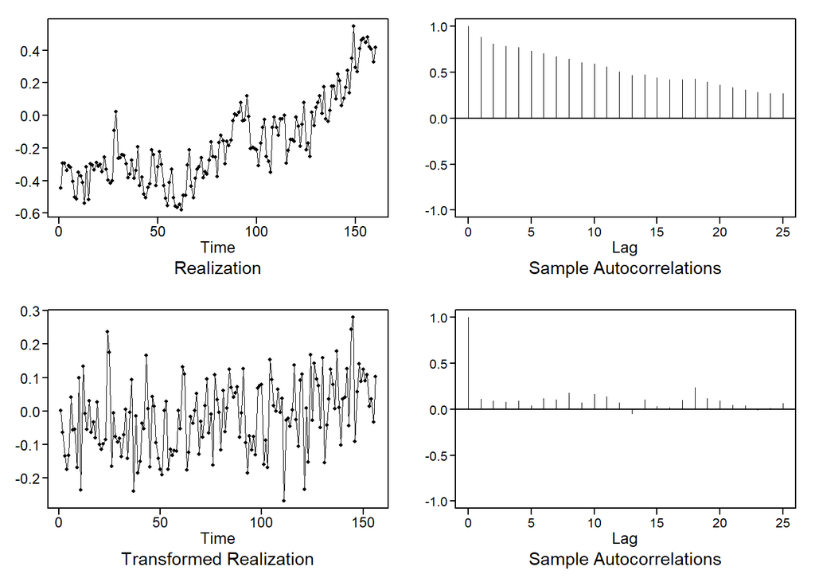

3. Transform the independent variable (time)  
   $\widehat{T}_t=\widehat{\phi}_z(B)T_tT_1=1, T_2= etc.$  
   $\widehat{T}_t=$t.trans

```r
#ar.z$phiis vector of ar.z$pestimated AR coefficients
t.trans=artrans.wge(t,phi.tr=ar.z$phi)
```

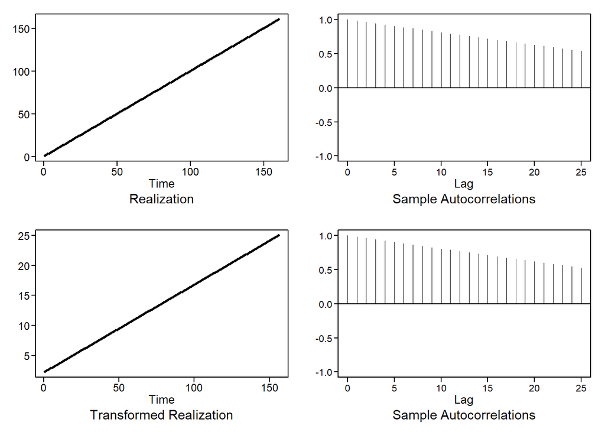

4. Regress $\widehat{Y}_t$ on $\widehat{T}_t$ using OLS.

```r
fitco = lm(y.trans~t.trans)
summary(fitco)
```

```
##
## Call:
## lm(formula = y.trans ~ t.trans)
##
## Residuals:
##      Min       1Q   Median       3Q      Max
## -0.28059 -0.07673  0.00269  0.06891  0.29897
##
## Coefficients:
##              Estimate Std. Error t value Pr(>|t|)
## (Intercept) -0.094089   0.018883  -4.983 1.67e-06 ***
## t.trans      0.005700   0.001248   4.566 1.01e-05 ***
## ---
## Signif. codes:  0 '***' 0.001 '**' 0.01 '*' 0.05 '.' 0.1 ' ' 1
##
## Residual standard error: 0.1025 on 154 degrees of freedom
## Multiple R-squared:  0.1192, Adjusted R-squared:  0.1135
## F-statistic: 20.85 on 1 and 154 DF,  p-value: 1.011e-05
```

After accounting for the serial correlation (AR(4)), there is strong evidence to suggest that the slope is significantly different from zero (pvalue< .0001).

**Evaluating residuals (after Cochrane-Orcutt)**

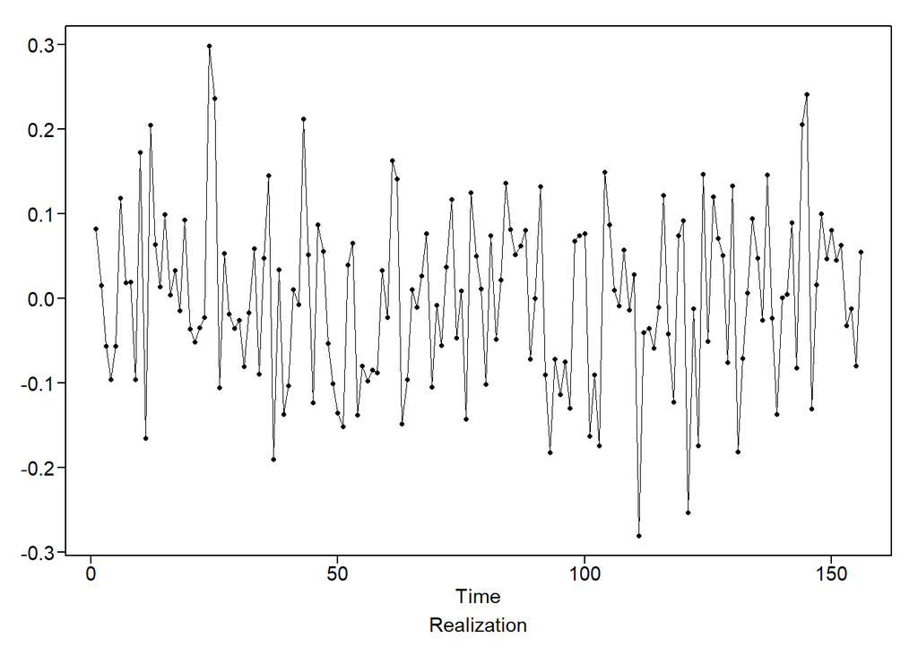

```r
plotts.wge(fitco$residuals)
```

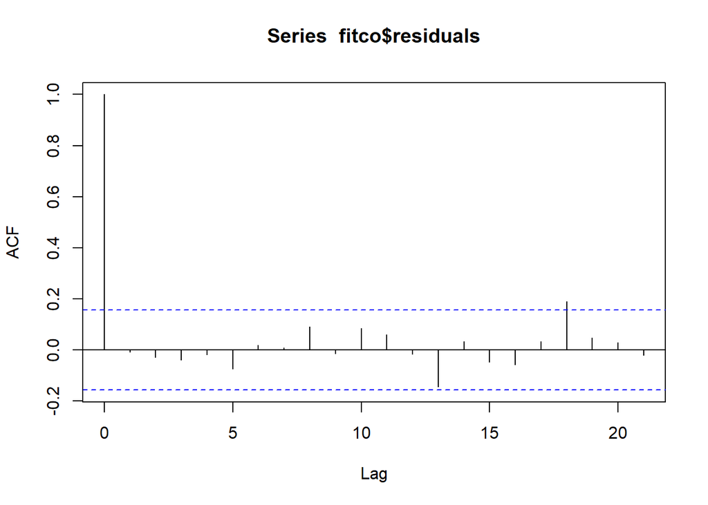

```r
acf(fitco$residuals)
```

```r
ljung.wge(fitco$residuals)
```

```
## Obs -0.008737864 -0.02921051 -0.03983496 -0.01880544 -0.07390092 0.01881816 0.007989357 0.08985609 -0.01477089 0.08345678 0.0596407 -0.0161459 -0.1431877 0.03329463 -0.04695007 -0.05698862 0.03235119 0.1895533 0.04799632 0.02905923 -0.02051948 -0.01792772 -0.06858885 -0.05010207
```

```
## $test
## [1] "Ljung-Box test"
##
## $K
## [1] 24
##
## $chi.square
## [1] 17.95885
##
## $df
## [1] 24
##
## $pval
## [1] 0.8049998
```

```r
ljung.wge(fitco$residuals, K=48)
```

```
## Obs -0.008737864 -0.02921051 -0.03983496 -0.01880544 -0.07390092 0.01881816 0.007989357 0.08985609 -0.01477089 0.08345678 0.0596407 -0.0161459 -0.1431877 0.03329463 -0.04695007 -0.05698862 0.03235119 0.1895533 0.04799632 0.02905923 -0.02051948 -0.01792772 -0.06858885 -0.05010207 -0.0005689194 0.0…
```

```
## $test
## [1] "Ljung-Box test"
##
## $K
## [1] 48
##
## $chi.square
## [1] 45.49179
##
## $df
## [1] 48
##
## $pval
## [1] 0.5762013
```

Sample autocorrelations tend to stay within limit lines and Ljung-Box test has p-values of .805 and .577 for K=24 and 48 respectively.

**Estimated signal-plus-noise model:**  
The slope and intercept comes from the d variable.

```r
#hadely = a + bt
summary(d)
```

```
##
## Call:
## lm(formula = x ~ t)
##
## Residuals:
##      Min       1Q   Median       3Q      Max
## -0.33041 -0.11126 -0.00045  0.11489  0.42004
##
## Coefficients:
##               Estimate Std. Error t value Pr(>|t|)
## (Intercept) -0.5257370  0.0251087  -20.94   <2e-16 ***
## t            0.0044378  0.0002705   16.40   <2e-16 ***
## ---
## Signif. codes:  0 '***' 0.001 '**' 0.01 '*' 0.05 '.' 0.1 ' ' 1
##
## Residual standard error: 0.1581 on 158 degrees of freedom
## Multiple R-squared:   0.63,  Adjusted R-squared:  0.6277
## F-statistic: 269.1 on 1 and 158 DF,  p-value: < 2.2e-16
```

```r
#Xt = (Intercept) -0.5257370 + t 0.0044378
```

The phi’s and WNV comes from the ar.z variable.

```r
#Phi's and White Noise Var
ar.z$vara
```

```
## [1] 0.01033484
```

```r
factor.wge(ar.z$phi)
```

```
##
## Coefficients of Original polynomial:
## 0.6140 -0.0440 0.0777 0.2063
##
## Factor                 Roots                Abs Recip    System Freq
## 1-0.9215B              1.0852               0.9215       0.0000
## 1-0.2079B+0.4345B^2    0.2392+-1.4981i      0.6591       0.2248
## 1+0.5154B             -1.9403               0.5154       0.5000
##
##
```

All of this information is in the fore.sigplusnoise.wge function as well.

**Note 1:** The above is the signal-plus-noise fit to the temperature data. Cochrane-Orcutt is a procedure to assess the significance of the slope (adjusting for the correlated errors).  
**Note 2:** We had to code the Cochrane-Orcutt Procedure manually since the function cochrane.orcutt() is only for AR(1) correlation.

**Forecasts using Signal-Plus-Noise Model**

```r
fore.sigplusnoise.wge(hadley,max.p = 4,n.ahead = 50,limits = FALSE)
```

```
##
## Coefficients of Original polynomial:
## 0.6148 -0.0374 0.0693 0.1905
##
## Factor                 Roots                Abs Recip    System Freq
## 1-0.9101B              1.0988               0.9101       0.0000
## 1-0.2113B+0.4132B^2    0.2557+-1.5346i      0.6428       0.2237
## 1+0.5066B             -1.9741               0.5066       0.5000
##
##
```

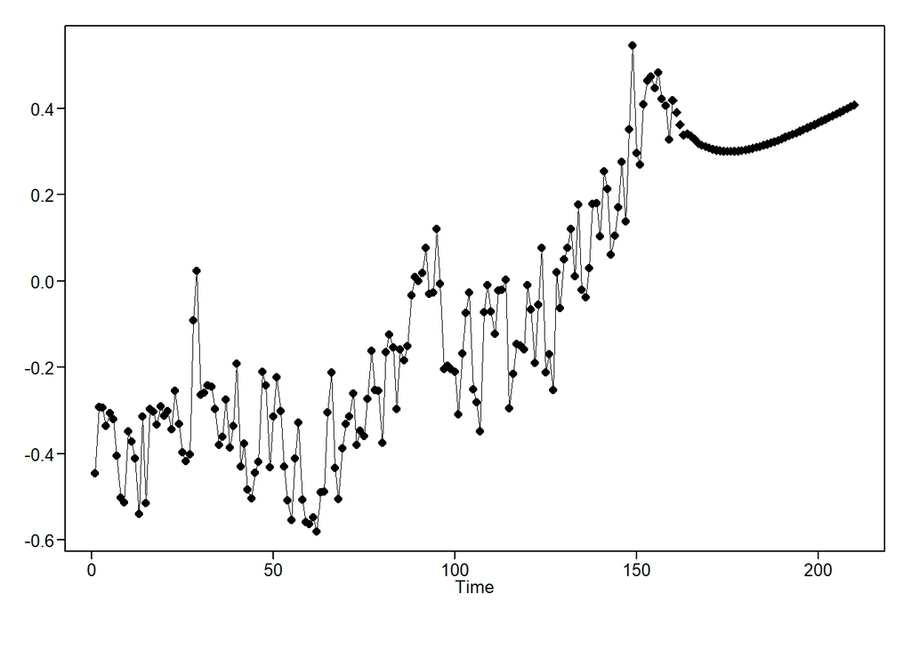

[output not shown]

[output cut: 179 more lines]

Interestingly, the forecasts suggest an initial decline but eventually predict the trend to continue.

**Important Points**

- Realizations from AR (ARMA/ARUMA) models have random trends
- Unless there are 2-unit roots, these models will not forecast a trend to continue
- Realizations from Xt= St+ Zt have deterministic trends
- If conditions do not change, then these trends will be forecast to continue
- Regarding the temperature data, if there is a deterministic signal in the data, it almost assuredly is not simply a straight line

**Final Thoughts for Temperature Data**

- All three models (ARMA, ARIMA, and signal-plus-noise) seemed to be satisfactory models from the standpoint of
  - Residual analysis
  - Realizations generated
- However, the three produced strikingly different forecasts
- Knowledge of the physical situation can help guide you, incorrect assumptions may lead you to the wrong conclusion
- We can’t stress enough:

**Beware of results by analysts who choose a model in order to produce desired results**

#### Sunspot Data: 1749-1924 (sunspot.classic)

**Sunspot Data: Box-Jenkins Model**

The Box-Jenkins procedure involves plotting the sample autocorrelations and sample partial autocorrelations and looking for patterns.  
Sample autocorrelations and partial autocorrelations can be obtained using base R functions:

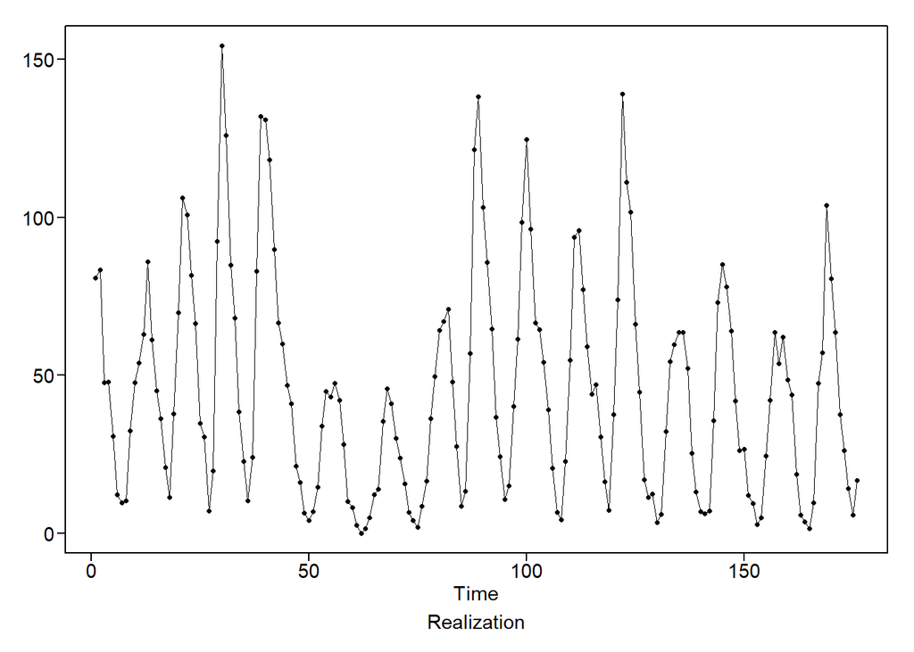

```r
data("sunspot.classic")
plotts.wge(sunspot.classic)
```

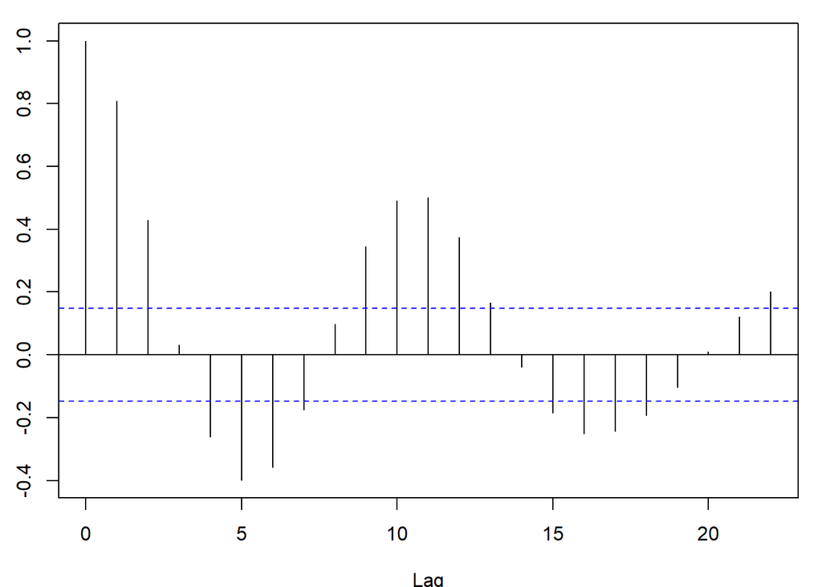

```r
acf(sunspot.classic)
```

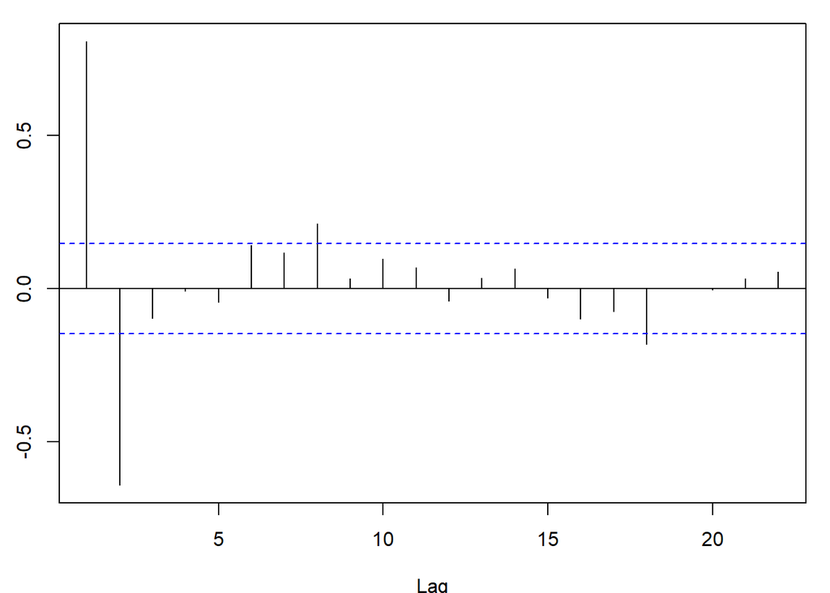

```r
pacf(sunspot.classic)
```

The two large partial autocorrelations strongly suggest an AR(2)  
Box and Jenkins fit an AR(2) model to the data. Using MLE estimates for the AR(2) we obtain:

```r
s2=est.ar.wge(sunspot.classic,p=2)
```

```
##
## Coefficients of Original polynomial:
## 1.3347 -0.6474
##
## Factor                 Roots                Abs Recip    System Freq
## 1-1.3347B+0.6474B^2    1.0308+-0.6943i      0.8046       0.0943
##
##
##
## Coefficients of Original polynomial:
## 1.3347 -0.6474
##
## Factor                 Roots                Abs Recip    System Freq
## 1-1.3347B+0.6474B^2    1.0308+-0.6943i      0.8046       0.0943
##
##
```

```r
#phi's
s2$phi
```

```
## [1]  1.3347282 -0.6474423
```

```r
#WNV
s2$avar
```

```
## [1] 235.993
```

```r
mean(sunspot.classic)
```

```
## [1] 44.78409
```

$$(1-1.33B+0.65B^2)(X_t-44.78)=a_t\\ where\ \widehat{\sigma}^2_a=236$$

The factor table shows that this model is associated with a pseudo-cyclic behavior with frequency $f_0=0.094$ or cycle length 1/.094=10.6 years which is consistent with the data.

Test with the ljung

```r
ljung.wge(s2$res, K=24)
```

```
## Obs -0.06954708 0.07075659 -0.05108517 0.0974615 -0.02894567 0.03356652 -0.07922662 0.08595523 0.1277246 0.08352318 0.1657183 0.1138884 -0.0008889926 -0.02771057 -0.0008302969 -0.08878259 0.08758083 -0.09060291 -0.01614403 -0.03566598 -0.05995891 0.09727939 0.02491359 0.01866973
```

```
## $test
## [1] "Ljung-Box test"
##
## $K
## [1] 24
##
## $chi.square
## [1] 26.93038
##
## $df
## [1] 24
##
## $pval
## [1] 0.307709
```

```r
ljung.wge(s2$res, K=48)
```

```
## Obs -0.06954708 0.07075659 -0.05108517 0.0974615 -0.02894567 0.03356652 -0.07922662 0.08595523 0.1277246 0.08352318 0.1657183 0.1138884 -0.0008889926 -0.02771057 -0.0008302969 -0.08878259 0.08758083 -0.09060291 -0.01614403 -0.03566598 -0.05995891 0.09727939 0.02491359 0.01866973 -0.002860187 -0.0…
```

```
## $test
## [1] "Ljung-Box test"
##
## $K
## [1] 48
##
## $chi.square
## [1] 62.83871
##
## $df
## [1] 48
##
## $pval
## [1] 0.07378717
```

**Sunspot Data: AIC Model Selection**

We next let AIC select a model for the sunspot data. We have chosen to select the best AR model using the code below:

```r
aic5.wge(sunspot.classic,p=0:10,q=0:0)
```

```
## ---------WORKING... PLEASE WAIT...
##
##
## Five Smallest Values of  aic
```

```
##       p    q        aic
## 9     8    0   5.461687
## 10    9    0   5.468713
## 11   10    0   5.475731
## 8     7    0   5.494449
## 4     3    0   5.495997
```

AIC picks an AR(8)

The factor table shown below also has a dominant frequency associated with the 10.5 year period.

```r
# FYI BIC selects an AR(2)
s8=est.ar.wge(sunspot.classic,p=8)
```

```
##
## Coefficients of Original polynomial:
## 1.2287 -0.4733 -0.1381 0.1569 -0.1403 0.0705 -0.1284 0.2069
##
## Factor                 Roots                Abs Recip    System Freq
## 1-1.5565B+0.8970B^2    0.8676+-0.6017i      0.9471       0.0965
## 1-0.8771B              1.1402               0.8771       0.0000
## 1-0.4147B+0.6550B^2    0.3166+-1.1944i      0.8093       0.2088
## 1+0.7964B             -1.2557               0.7964       0.5000
## 1+0.8231B+0.5043B^2   -0.8161+-1.1476i      0.7101       0.3484
##
##
##
## Coefficients of Original polynomial:
## 1.2287 -0.4733 -0.1381 0.1569 -0.1403 0.0705 -0.1284 0.2069
##
## Factor                 Roots                Abs Recip    System Freq
## 1-1.5565B+0.8970B^2    0.8676+-0.6017i      0.9471       0.0965
## 1-0.8771B              1.1402               0.8771       0.0000
## 1-0.4147B+0.6550B^2    0.3166+-1.1944i      0.8093       0.2088
## 1+0.7964B             -1.2557               0.7964       0.5000
## 1+0.8231B+0.5043B^2   -0.8161+-1.1476i      0.7101       0.3484
##
##
```

```r
# s8$phi: 1.22872595 -0.47331327 -0.13807811 0.15688938 -0.14030802 0.07050449 -0.12841889 0.20692558
# s8$avar:212.6003
mean(sunspot.classic) # 44.78409
```

```
## [1] 44.78409
```

Look at the residuals

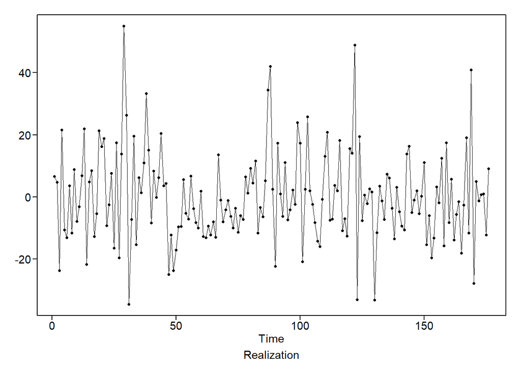

```r
plotts.wge(s8$res)
```

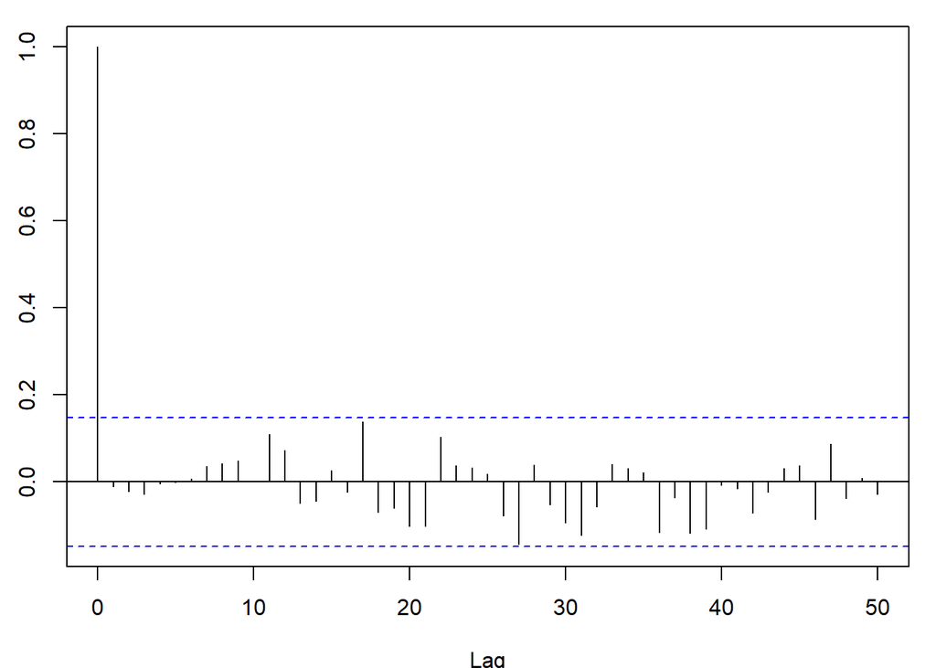

```r
acf(s8$res, lag.max = 50)
```

```r
ljung.wge(s8$res, K= 24)
```

```
## Obs -0.01056141 -0.02213369 -0.02764792 -0.004084051 -0.001672975 0.006984793 0.03574733 0.04213578 0.04804272 0.001446534 0.1095911 0.07271027 -0.04872425 -0.04428607 0.02645631 -0.02262032 0.1388003 -0.06893564 -0.0596409 -0.1023278 -0.1019947 0.1026266 0.03778485 0.03258495
```

```
## $test
## [1] "Ljung-Box test"
##
## $K
## [1] 24
##
## $chi.square
## [1] 17.9297
##
## $df
## [1] 24
##
## $pval
## [1] 0.8064054
```

```r
ljung.wge(s8$res, K= 48)
```

```
## Obs -0.01056141 -0.02213369 -0.02764792 -0.004084051 -0.001672975 0.006984793 0.03574733 0.04213578 0.04804272 0.001446534 0.1095911 0.07271027 -0.04872425 -0.04428607 0.02645631 -0.02262032 0.1388003 -0.06893564 -0.0596409 -0.1023278 -0.1019947 0.1026266 0.03778485 0.03258495 0.01838261 -0.07789…
```

```
## $test
## [1] "Ljung-Box test"
##
## $K
## [1] 48
##
## $chi.square
## [1] 45.8185
##
## $df
## [1] 48
##
## $pval
## [1] 0.5626712
```

**11.6.5 Check**  
Assume an AR model (q = 0) for the Sunspot data, and use aic5.wge() to estimate the top five models based on AIC. (*Make sure to allow the function to search up to an AR model with p = 10.)  
Are both an AR(2) and an AR(8) in the top five?  
**No**

```r
aic5.wge(sunspot.classic, p=0:10,q=0)
```

```
## ---------WORKING... PLEASE WAIT...
##
##
## Five Smallest Values of  aic
```

```
##       p    q        aic
## 9     8    0   5.461687
## 10    9    0   5.468713
## 11   10    0   5.475731
## 8     7    0   5.494449
## 4     3    0   5.495997
```

**11.6.6 Check**  
What is the AIC of the AR(8) fit? Express your response rounded to four decimals.  
**$value [1] 5.461687**

```r
aic.wge(sunspot.classic, p=8, q=0)
```

```
## $type
## [1] "aic"
##
## $value
## [1] 5.461687
##
## $p
## [1] 8
##
## $q
## [1] 0
##
## $phi
## [1]  1.22872595 -0.47331327 -0.13807811  0.15688938 -0.14030802  0.07050449
## [7] -0.12841889  0.20692558
##
## $theta
## [1] 0
##
## $vara
## [1] 212.6003
```

#### Erata

11.3.1 There is no code. Here is the code:

data(airlog) # load from tswge package airlog1 = artrans.wge(airlog,phi.tr=1) airlog1.12 = artrans.wge(airlog1,phi.tr = c(rep(0,11),1)) ww = est.ar.wge(airlog1.12,p = 12)

11.3.2

To run the Llung-Box test, use K = 24 You should get a pvalue of .01645 # this is the correct answer but the computer has a different answer.

The computer will want .4969

11.3.3

The computer will want “YES” but the answer is actually “NO” since the pvalue in the last questions changed from above .05 to below .05. (FTR Ho to Reject Ho).

11.6.2 The model specification in the video is listed as .33 instead of 1.33 (missing the 1.)